```python
import pandas as pd
from pandas.compat import StringIO
import re
import matplotlib as plt
```

# Process and Outcome Evaluation of the Gang Resistance Education and Training (G.R.E.A.T.) Program, 2006-2011

## Data Documentation (ICPSR 34899)

> August 19 , 2019

Source: https://www.icpsr.umich.edu/icpsrweb/NACJD/studies/34899/datadocumentation

In this writeup we:

- Summarize the reference study
- Extract some relevant content from the codesheet pdf file provided as part of the G.R.E.A.T. restricted dataset documentation -where aggregate stats for each variable are provided-, parse it into a CSV, and then read it, clean it and show how some of its relevant variables can be analyzed using pandas.

### G.R.E.A.T

The Gang Resistance Education and Training (G.R.E.A.T.) program is a gang and delinquency prevention 13-lesson program delivered by law enforcement officers within a school setting. Developed locally in 1991 in Phoenix, the program quickly spread throughout the US.

Results from an earlier National Evaluation (1995-2001) found that the **had an effect on several mediating variables** associated with gang membership and delinquency but found **no differences between G.R.E.A.T. and non-G.R.E.A.T. youths** in terms of gang membership and involvement in delinquent behavior. Based in part on these findings, G.R.E.A.T. underwent a critical review that resulted in **substantial program modifications**.

In 2006, the National Institute of Justice awarded the University of Missouri-St. Louis funding to conduct a (second) National Evaluation of the G.R.E.A.T. program.

### The Data

To assess program effectiveness, researchers conducted a RCT involving **3,820 students nested in 195 classrooms in 31 schools in 7 cities**. A process evaluation consisted of multiple methods to assess program fidelity: 1) observations of G.R.E.A.T. Officer Trainings, 2) surveys and interviews of G.R.E.A.T.-trained officers and supervisors, 3) surveys of school personnel, and 4) "on-site," direct observations of officers delivering the G.R.E.A.T. program in the study sites.

Among US cities participating in G.R.E.A.T, the research team selected 7, **varying in size, region, and level of gang activity**, as primary target sites: Albuquerque, New Mexico; Chicago, Illinois; Greeley, Colorado; Nashville, Tennessee; Philadelphia, Pennsylvania; Portland, Oregon; and a city located in the Dallas-Fort Worth (DFW), Texas area.

Only the data from the student surveys, law enforcement officer surveys, and school personnel surveys are available. Dataset 1 (Student Survey) has 3,820 cases and 1,926 variables. Dataset 2 (Law Enforcement Survey) has 137 cases and 140 variables. Dataset 3 (School Personnel Survey) has 230 cases and 148 variables.

*Variable Notation/Naming Conventions: V#1###2 where #1=Wave Number and ###2= Variable Number*

### The Study

The outcome evaluation employs an experimental longitudinal panel design (an RCT with long-term follow-up) where treatment is the G.R.E.A.T. program.

All students for whom active parental consent was obtained (3,820) were then asked to participate in the evaluation by completing a confidential group-administered pre-test questionnaire. Upon completion of the G.R.E.A.T. program in each school, students were then requested to complete post-tests and four annual follow-up surveys. Retention rates were excellent: 98.3% completed the pre-test, 94.6% completed the post-test, and 87.3% completed the one-year post-program survey.

The study:

- Surveys students attending 31 public middle schools in the 7 cities mentioned above.
- Uses the student responses to multiple waves of questionnaires (pre-test, post-test, and annual follow-up surveys in each of the following four years) to assess short- and long-term **program effects**, i.e. the extent to which students receiving G.R.E.A.T. differ from non-G.R.E.A.T. students in terms of their **delinquent activity and gang involvement**.
- Additionally, examines the extent to which risk factors addressed in the G.R.E.A.T. program also differentiate the G.R.E.A.T. students from the control group.

G.R.E.A.T. has three stated goals: 1) to reduce gang membership, 2) to reduce delinquency, especially violent offending, and 3) to improve students' attitudes toward the police. The goal of the [Esbenses et al.](https://www.umsl.edu/ccj/pdfs/great/GREAT%20II%20Short%20Term%20Results) is to determine what effect, if any, the program had on students in terms of such 3 goals. In the study:

- **Gang membership** is measured by a single-item question that is part of a larger set of questions about youth gangs: “Are you now in a gang?”.
- To measure **delinquency and violent offending**, students completed a 15-item self-reported delinquency inventory treated as a composite measure of general delinquency, but also created a separate measure of violent offending consisting of three items (attacked someone with a weapon, used a weapon or force to get money or things from people, been involved in gang fights).
- **Improving relations with law enforcement**, is measured by six questions tapping global attitudes to the police as well as two additional questions measuring students’ attitudes about police officers as teachers.

The analyses also included **26 proximal outcome measures** (in addition to the five program outcomes discussed above) that tapped the extent to which the students enrolled in the G. R.E.A.T. program developed skills and attitudes that were promoted through- out the G.R.E.A.T. curriculum.

## Aggregate Data Exploration

This uses aggregate staistics for each variable, as made available in the Codesheet pdf file.

### Helper Functions:

```python
def setprev(df, col_lst): #### substitute NaN for previous value for each col listed
    for col in col_lst:
        for i in range(1, len(df)):
            if type(df[col].iloc[i])==float:
                df[col].iloc[i]= df[col].iloc[i-1]
    return df

#### Extract mean and SE from col 5:

def getSE(x): # this function is applied to each value of the column via map/apply
    if x and type(x) != float:
        if re.compile( "\((.*)\)" ).search(x):
            se =  re.compile( "\((.*)\)" ).search(x).group(1)
            se = se.strip(' ')
            if len(se) < 4:
                return float('0'+ se)
            else:
                return float(se)

def get_mean(x): # this function is applied to each value of the column via map/apply
    if x and type(x) != float:
        m = x.split('(')[0]
        m = m.strip(' ')
        if len(m) < 4:
            return float('0'+ m)
        else:
            try:
                return float(m)
            except:
                return m

def remove_char(x, ch):
    if x and type(x)!= float:
        return x.strip(ch)

def divdot(x, char, i):
    if x and type(x)!= float and char in x:
        return  x.split(char)[i]

def tonum(df, colnum):
    for i, x in enumerate(df.iloc[: , colnum]):
        if type(x) != float and (len(x) > 5 or '(' in x):
            x = df.iloc[: , colnum+1][i]
        try:
            x = float(x)
        except:
            x=x
    return df

def get_wave(x):
    if type(x) != float and 'V' in x:
        if 'V1' in x:
            return 'W1'
        elif 'V2' in x:
            return 'W2'
        elif 'V3' in x:
            return 'W3'
        elif 'V4' in x:
            return 'W4'
        elif 'V5' in x:
            return 'W5'
        else:
            return 'W6'

# Plot answer %
def plotvar(df, var, color='#3C9CC1'):
    df['summ'] = pd.to_numeric(df['summ'], errors='coerce')
    dfm = df[df['var_name'] == var].sort_values("summ")
    dfm.plot.barh(x='val', y='summ', title= dfm['lab'].iloc[0], color= color)

# Plot answer stats
def plotvar_stats(df, var_lst, stat, color='red'):
    df[stat] = pd.to_numeric(df[stat], errors='coerce')
    dfm = df[df['var_name'].isin(var_lst)]
    return dfm
```

## I. STUDENT SURVEY CODEBOOKS: Waves 1 - 6

### 1. Read and clean data

```python
df_st = pd.read_table('codebook.csv', sep=",")
```

```python
df_st = df_st.iloc[:,0:-2]
```

```python
cols = list(df_st.columns)
newcols = ['var_name', 'lab', 'val', 'summ', 'mean_sd' ]
recols = {newcols[i]: cols[i] for i in range(len(cols))}
df_st.columns = newcols
```

```python
df_st = setprev(df_st, ['var_name', 'lab', 'mean_sd'])
df_st['var_name'] = df_st['var_name'].apply(remove_char, args=(' '))
```

```python
df_st['wave'] = df_st['var_name'].apply(get_wave) # set Wave No. as a new column
df_st['mean']= df_st['mean_sd'].apply(get_mean)
df_st['se']= df_st['mean_sd'].apply(getSE)
df_st['ans_val']= df_st['val'].apply(divdot, args=('.', 0))
df_st['ans_def'] = df_st['val'].apply(divdot, args=('.', 1))
```

### 2. Dataframe overview

```python
df_st['var_name'].nunique() # no. questions
```

```
1926
```

```python
df_st.tail()
```

|  | var_name | lab | val | summ | mean_sd | wave | mean | se | ans_val | ans_def |
| --- | --- | --- | --- | --- | --- | --- | --- | --- | --- | --- |
| 10703 | V6381 | N1 12. Sex/Get girls/boys | 1. No | 71.7 | 1.32 (.60) | W6 | 1.32 | 0.6 | 1 | No |
| 10704 | V6381 | N1 12. Sex/Get girls/boys | 2. Yes | 0.2 | 1.32 (.60) | W6 | 1.32 | 0.6 | 2 | Yes |
| 10705 | V6382 | N2 11. Family would get hurt or killed | 1. No | 71.8 | 1.32 (.60) | W6 | 1.32 | 0.6 | 1 | No |
| 10706 | V6382 | N2 11. Family would get hurt or killed | 2. Yes | 0.1 | 1.32 (.60) | W6 | 1.32 | 0.6 | 2 | Yes |
| 10707 | V6382 | 180 | NaN | NaN | 1.32 (.60) | W6 | 1.32 | 0.6 | None | None |

### 3. Plot Response Distribution

We can do this for any variable (and condition on wave no. if needed). For example:

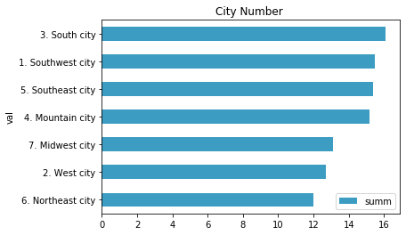

```python
plotvar(df_st, 'city' )
```

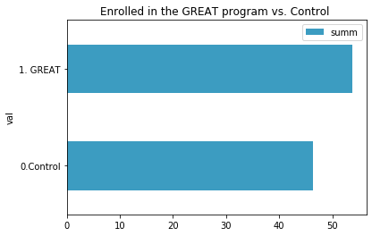

```python
plotvar(df_st, 'great' ) # enrolled vs. non-enrolled in program
```

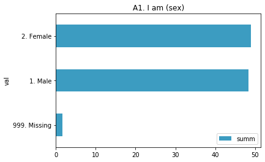

```python
plotvar(df_st, 'V1001' )
```

```python
vars_to_plot = list(df_st['var_name'].unique())[1:21] # just define a list of vars of interest
```

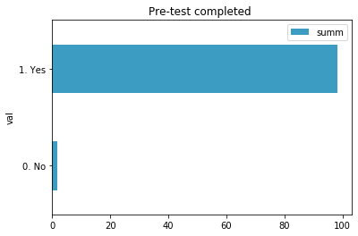

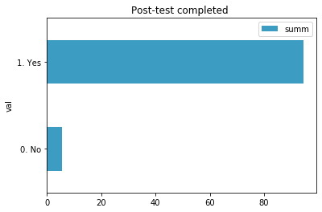

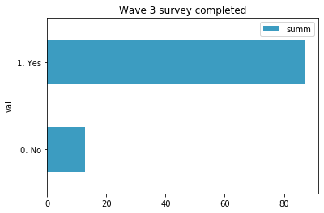

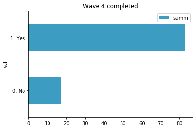

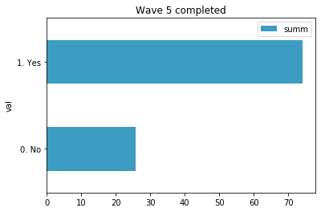

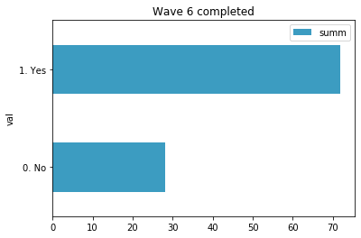

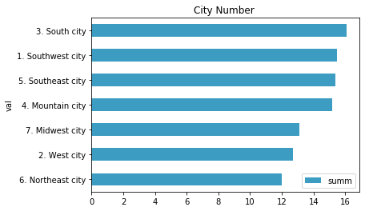

[figure not shown]

[figure not shown]

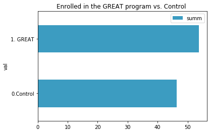

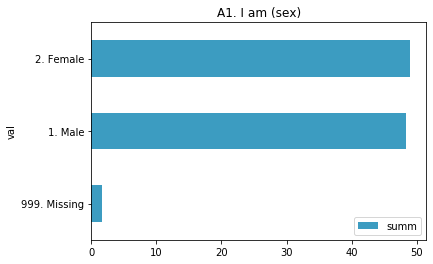

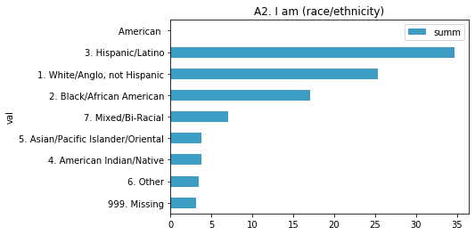

[8 more figures not shown]

```python
for var in vars_to_plot:
    plotvar(df_st, var )
```

The two following datasets are not the focus of the study but we'll process them a bit just to clean them:

## II. LAW ENFORCEMENT PERSONNEL SURVEY

```python
df_law = pd.read_table('codebook-surv2.csv', sep=",")
```

```python
df_law.head()
```

|  | Variable | Variable Label | Value and Label | N | % | Mean (SD) | Unnamed: 6 |
| --- | --- | --- | --- | --- | --- | --- | --- |
| 0 | QNUM | Questionnaire Number | Number | NaN | NaN | NaN | NaN |
| 1 | NaN | NaN | 999. Missing | 0.0 | 0.0% | NaN | NaN |
| 2 | VAR00002 | A1. 1. Rank/Title: School Resource | 1. No | 56.0 | 40.9% | NaN | NaN |
| 3 | NaN | / Youth Officer | 2. Yes | 81.0 | 59.1% | NaN | NaN |
| 4 | NaN | NaN | 999. Missing | 0.0 | 0.0% | NaN | NaN |

```python
df_law = df_law.iloc[:,0:-1]
newcols2 = ['var_name', 'lab', 'val', 'N', 'summ', 'mean_sd']
df_law.columns = newcols2
```

```python
df_law['mean']= df_law['mean_sd'].apply(get_mean)
df_law['se']= df_law['mean_sd'].apply(getSE)
df_law['summ'] = df_law['summ'].apply(remove_char, args=('%'))
df_law['q']= df_law['val'].apply(divdot, args=('.', 0))
df_law['var_val'] = df_law['val'].apply(divdot, args=('.', 1))
```

```python
df_law = setprev(df_law, ['var_name', 'lab', 'mean_sd'])
```

```python
df_law.head()
```

|  | var_name | lab | val | N | summ | mean_sd | mean | se | q | var_val |
| --- | --- | --- | --- | --- | --- | --- | --- | --- | --- | --- |
| 0 | QNUM | Questionnaire Number | Number | NaN | None | NaN | None | NaN | None | None |
| 1 | QNUM | Questionnaire Number | 999. Missing | 0.0 | 0.0 | NaN | None | NaN | 999 | Missing |
| 2 | VAR00002 | A1. 1. Rank/Title: School Resource | 1. No | 56.0 | 40.9 | NaN | None | NaN | 1 | No |
| 3 | VAR00002 | / Youth Officer | 2. Yes | 81.0 | 59.1 | NaN | None | NaN | 2 | Yes |
| 4 | VAR00002 | / Youth Officer | 999. Missing | 0.0 | 0.0 | NaN | None | NaN | 999 | Missing |

## III. SURVEY OF SCHOOL PERSONNEL

```python
df_sp = pd.read_table('codebook-surv3.csv', sep=",")
```

```python
df_sp.head()
```

|  | var_name | var_lab | value | N | % | Mean (SD) | Unnamed: 6 |
| --- | --- | --- | --- | --- | --- | --- | --- |
| 0 | QNUM | Questionnaire Number | NaN | NaN | NaN | NaN | NaN |
| 1 | V002 | A1. Problems at school: | 1. Not a problem | 104 | 45.2% | 1.72 (.74) | NaN |
| 2 | NaN | School over-crowding | 2. Somewhat of a problem | 86 | 37.4% | NaN | NaN |
| 3 | NaN | NaN | 3. A big problem | 39 | 17.0% | NaN | NaN |
| 4 | NaN | NaN | 999. Missing | 1 | 0.4% | NaN | NaN |

```python
df_sp = df_sp.iloc[:,0:-1]
```

```python
df_sp.head()
```

|  | var_name | var_lab | value | N | % | Mean (SD) |
| --- | --- | --- | --- | --- | --- | --- |
| 0 | QNUM | Questionnaire Number | NaN | NaN | NaN | NaN |
| 1 | V002 | A1. Problems at school: | 1. Not a problem | 104 | 45.2% | 1.72 (.74) |
| 2 | NaN | School over-crowding | 2. Somewhat of a problem | 86 | 37.4% | NaN |
| 3 | NaN | NaN | 3. A big problem | 39 | 17.0% | NaN |
| 4 | NaN | NaN | 999. Missing | 1 | 0.4% | NaN |

```python
newcols3 = ['var_name', 'lab', 'val', 'N', 'summ', 'mean_sd']
df_sp.columns = newcols3
```

```python
df_sp['mean']= df_sp['mean_sd'].apply(get_mean)
df_sp['se']= df_sp['mean_sd'].apply(getSE)
```

```python
df_sp['summ'] = df_sp['summ'].apply(remove_char, args=('%'))
df_sp['ans_val']= df_sp['val'].apply(divdot, args=('.', 0))
df_sp['ans_def'] = df_sp['val'].apply(divdot, args=('.', 1))
```

```python
df_sp = setprev(df_sp, ['var_name', 'lab', 'mean_sd'])
```

```python
df_sp.head()
```

|  | var_name | lab | val | N | summ | mean_sd | mean | se | ans_val | ans_def |
| --- | --- | --- | --- | --- | --- | --- | --- | --- | --- | --- |
| 0 | QNUM | Questionnaire Number | NaN | NaN | None | NaN | None | NaN | None | None |
| 1 | V002 | A1. Problems at school: | 1. Not a problem | 104 | 45.2 | 1.72 (.74) | 1.72 | 0.74 | 1 | Not a problem |
| 2 | V002 | School over-crowding | 2. Somewhat of a problem | 86 | 37.4 | 1.72 (.74) | None | NaN | 2 | Somewhat of a problem |
| 3 | V002 | School over-crowding | 3. A big problem | 39 | 17.0 | 1.72 (.74) | None | NaN | 3 | A big problem |
| 4 | V002 | School over-crowding | 999. Missing | 1 | 0.4 | 1.72 (.74) | None | NaN | 999 | Missing |